# PLSC30500, Fall 2024

Part 4. Regression (part b)

Andy Eggers

# The math behind OLS

## Motivation

OLS estimator:
$$(\hat{\beta_0}, \hat{\beta_1}, \ldots, \hat{\beta_K}) = \underset{(b_0, b_1, \ldots, b_K) \in \mathbb{R}^{K+1}}{\arg\min} \, \frac{1}{n}\sum_{i =1}^n\, \left(Y - (b_0 + b_1X_{[1]} + \ldots + b_K X_{[K]})\right)^2$$

Could solve by trying every combination of $b_0, b_1, \ldots, b_K$.

Let’s try to understand a more efficient solution:
$$\hat{\boldsymbol{\beta}} = \left( \mathbb{X}^T \mathbb{X} \right)^{-1} \mathbb{X}^T \mathbf{Y}$$

## The case of one predictor

$$(\hat{\beta_0}, \hat{\beta_1}) = \underset{(b_0, b_1) \in \mathbb{R}^{2}}{\arg\min} \, \frac{1}{n} \sum_{i =1}^n\, \left(Y_i - (b_0 + b_1X_i)\right)^2$$

Expanding the sum, $S$, we get

$$\begin{align}
S &= \sum_{i = 1}^n \left(Y_i^2 - 2\beta_0 Y_i - 2\beta_1 X_iY_i + \beta_0^2 + 2\beta_0 \beta_1 X_i + \beta_1^2 X_i^2\right) \\
&= \sum Y_i^2 - 2 \beta_0 \sum Y_i - 2\beta_1 \sum X_i Y_i + n \beta_0^2 + 2\beta_0 \beta_1 \sum X_i + \beta_1^2 \sum X_i^2
\end{align}$$

We want to choose $\beta_0$ and $\beta_1$ to minimize $S$.

## Review: optimization via differentiation

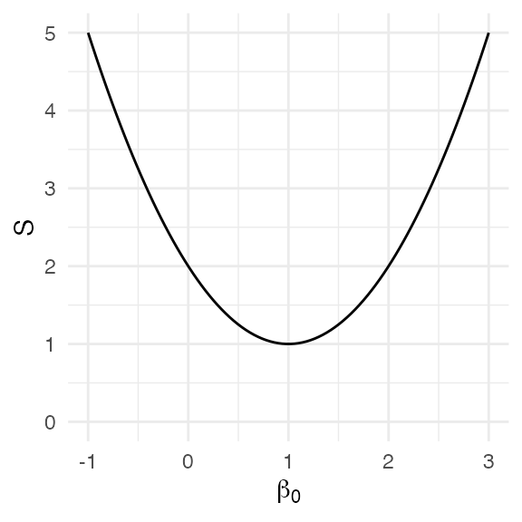

Observing that the function is flat only at the minimum, we use differentiation to obtain the **first order condition**:

$$\frac{\partial S}{\partial \beta_0} = -2 + 2 \beta_0 = 0$$

So the solution is $\beta_0 = 1$.

## Optimization in two dimensions

How would you choose $\beta_0$ and $\beta_1$ to minimize $S = -2\beta_0 + \beta_0^2 - 3 \beta_1 + \beta_1^2 + \beta_0 \beta_1$?

Taking same approach, first order conditions are

$$\begin{align}
\frac{\partial S}{\partial \beta_0} &= -2 + 2 \beta_0 + \beta_1 = 0 \\
\frac{\partial S}{\partial \beta_1} &= -3 + \beta_0 + 2\beta_1 = 0
\end{align}$$

A system of equations!

$$\begin{align}
2 \beta_0 + \beta_1 = 2 \\
\beta_0 + 2\beta_1 = 3
\end{align}$$

By isolating and substituting, we get $\beta_0 = 1/3$ and $\beta_1 = 4/3$.

## Back to our problem

To find $\beta_0$ and $\beta_1$ that minimize
$$S = \sum Y_i^2 - 2 \beta_0 \sum Y_i - 2\beta_1 \sum X_i Y_i + n \beta_0^2 + 2\beta_0 \beta_1 \sum X_i + \beta_1^2 \sum X_i^2,$$
we use the same approach.

$$\begin{align}
\frac{\partial S}{\partial \beta_0} &= -2 \sum Y_i + 2 n \beta_0 + 2\beta_1 \sum X_i &= 0\\
\frac{\partial S}{\partial \beta_1} &= -2 \sum X_i Y_i + 2 \beta_0 \sum X_i + 2 \beta_1 \sum X_i^2 &= 0
\end{align}$$

System of equations:

$$\begin{align}
n \beta_0 + \beta_1 \sum X_i &= \sum Y_i \\
\beta_0 \sum X_i + \beta_1 \sum X_i^2 &= \sum X_i Y_i
\end{align}$$

## Solving our system of equations

$$\begin{align}
n \beta_0 + \beta_1 \sum X_i &= \sum Y_i \\
\beta_0 \sum X_i + \beta_1 \sum X_i^2 &= \sum X_i Y_i
\end{align}$$

Isolating $\beta_0$ in the first equation, we get
$$\beta_0 = \frac{\sum Y_i}{n} - \beta_1 \frac{\sum X_i}{n}$$

Substituting into second equation, rearranging, dividing top & bottom by $n$, we get
$$\beta_1 = \frac{\frac{\sum X_iY_i}{n} - \frac{\sum X_i}{n}\frac{\sum Y_i}{n}}{\frac{\sum X_i^2}{n} - \left(\frac{\sum X_i}{n}\right)^2}$$

These are the sample analogues of the bivariate BLP (where $\beta_1 = \frac{\text{Cov}[X,Y]}{{\textrm V}\,[X]}$).

## Where are we?

We have shown how, with a bit of calculus, we can derive the OLS estimator in the case with one predictor.

If we want $K > 1$ predictors, could do the same thing:

- expand the sum $S$
- obtain $K + 1$ first order conditions
- solve by isolating and substituting

A horrible mess.

To make things easier, we turn to some **linear algebra**.

# Matrix basics

## A matrix

A matrix $\mathbb{B}$ is a rectangular table of numbers, e.g.

$$\mathbb{B} = \begin{bmatrix} 1 & 2 \\
4 & 0 \\
-1 & 3 \end{bmatrix}$$

This is a $3\times 2$ matrix (rows $\times$ columns).

The **transpose** of $\mathbb{B}$, written $\mathbb{B}^T$ or $\mathbb{B}'$, is

$$\mathbb{B}^T = \begin{bmatrix} 1 & 4 & -1\\
2 & 0 & 3 \end{bmatrix}.$$

$k$th row of $\mathbb{B}$ is $k$th column of $\mathbb{B}^T$ (and vice versa).

## Matrix multiplication

- A **column vector** of length $K$ is a matrix with one column and $K$ rows.
- A **row vector** of length $K$ is a matrix with one row and $K$ columns.

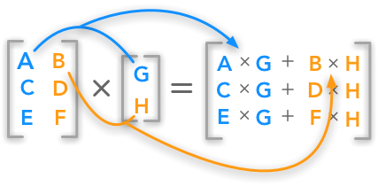

## Matrix multiplication more generally

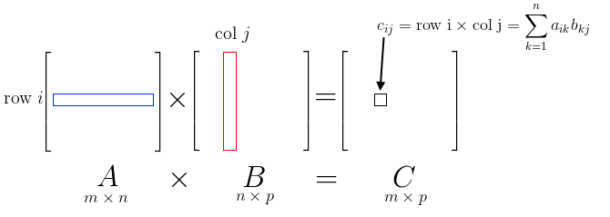

## Matrix manipulation in `R`

```r
# equivalent ways to make B:
B <- cbind(c(1, 4, -1), c(2, 0, 3))
(B <- matrix(data = c(1, 4, -1, 2, 0, 3), ncol = 2))
```

```
     [,1] [,2]
[1,]    1    2
[2,]    4    0
[3,]   -1    3
```

```r
t(B)
```

```
     [,1] [,2] [,3]
[1,]    1    4   -1
[2,]    2    0    3
```

```r
# also equivalent:
D <- c(2, 1)
(D <- matrix(data = c(2, 1), ncol = 1))
```

```
     [,1]
[1,]    2
[2,]    1
```

```r
B %*% D
```

```
     [,1]
[1,]    4
[2,]    8
[3,]    1
```

Can only multiply $\mathbb{B}$ and $\mathbf{D}$ if number of columns in $\mathbb{B}$ equals number of rows in $\mathbf{D}$.

## Our OLS problem in matrix algebra

Recall our system of equations:

$$\begin{align}
n \beta_0 + \beta_1 \sum X_i &= \sum Y_i \\
\beta_0 \sum X_i + \beta_1 \sum X_i^2 &= \sum X_i Y_i
\end{align}$$

We can write this in matrix form as

$$\mathbb{B} \boldsymbol{\beta} = \mathbf{D}$$

where

$$\mathbb{B} = \begin{bmatrix} n & \sum X_i \\
\sum X_i & \sum X_i^2 \end{bmatrix}, \, \, \, \,\, \boldsymbol{\beta} = \begin{bmatrix} \beta_0 \\
\beta_1 \end{bmatrix}, \, \, \, \,\, \mathbf{D} = \begin{bmatrix} \sum Y_i \\
\sum X_i Y_i \end{bmatrix}$$

## The inverse: concept

The *inverse* of a scalar (number) $a$ is written $a^{-1}$, and $a \times a^{-1} = 1$. (e.g. $3^{-1} = 1/3$, so $3 \times 1/3 = 1$.)

We multiply both sides by the inverse of $a$ when we do

$$\begin{align}
a x &= b \\
x &= b/a
\end{align}$$

The *inverse* of a matrix $\mathbb{B}$ is written $\mathbb{B}^{-1}$.

We can similarly solve our problem using the inverse of $\mathbb{B}$:

$$\begin{align}
\mathbb{B} \boldsymbol{\beta} &= \mathbf{D} \\
\boldsymbol{\beta} &= \mathbb{B}^{-1} \mathbf{D}
\end{align}$$

This is a useful way to represent the solution to a system of equations.

## The inverse: implementation

There are manual procedures for inverting matrices. We use `R`’s `solve()` function:

```r
# creating our matrices for one toy dataset
x <- c(1, 2, 3)
y <- c(1, 3, 3)
(B <- cbind(c(length(x), sum(x)), c(sum(x), sum(x^2))))
```

```
     [,1] [,2]
[1,]    3    6
[2,]    6   14
```

```r
(D <- c(sum(y), sum(x*y)))
```

```
[1]  7 16
```

```r
solve(B)%*%D # using inverse to solve the system of eqns
```

```
          [,1]
[1,] 0.3333333
[2,] 1.0000000
```

```r
# checking the solution
lm(y ~ x) |> coef()
```

```
(Intercept)           x
  0.3333333   1.0000000
```

So we have (1) a way to represent systems of equations and (2) a way to solve them.

# The general OLS estimator in matrix form

## OLS with $K$ predictors

Let $\mathbb{X}$ be the $n \times K + 1$ regressor matrix (a column of 1s and 1 column per predictor):

$$\mathbb{X} = \begin{bmatrix} 1 & X_{[1]1} & X_{[2]1} & \cdots & X_{[K]1} \\
1 & X_{[1]2} & X_{[2]2} & \cdots& X_{[K]2} \\
\vdots & \vdots & \vdots & \ddots & \vdots \\
1 & X_{[1]n} & X_{[2]n} & \cdots & X_{[K]n} \end{bmatrix}$$

Let $\boldsymbol{\beta}$ be the $K+1$-length column vector of coefficients:
$$\boldsymbol{\beta} = \begin{bmatrix} \beta_0 \\
\beta_1 \\
\vdots \\
\beta_{K} \end{bmatrix}$$

Let $\mathbf{Y}$ be the $n$-length column vector of outcomes:
$$\mathbf{Y} = \begin{bmatrix} Y_1 \\
Y_2 \\
\vdots \\
Y_{n} \end{bmatrix}$$

## OLS with $K$ predictors (2)

For a given coefficient vector $\boldsymbol{\beta}$,

- $\mathbb{X}\boldsymbol{\beta}$ is a column vector of **predictions**
- $\mathbf{Y} - \mathbb{X}\boldsymbol{\beta}$ is a column vector of **residuals**
- $(\mathbf{Y} - \mathbb{X}\boldsymbol{\beta})^T (\mathbf{Y} - \mathbb{X}\boldsymbol{\beta})$ is the **sum of squared residuals**

OLS estimator in matrix form:

$$(\hat{\beta_0}, \hat{\beta_1}, \ldots, \hat{\beta_K}) = \underset{(b_0, b_1, \ldots, b_K) \in \mathbb{R}^{K+1}}{\arg\min} \, (\mathbf{Y} - \mathbb{X}\boldsymbol{\beta})^T (\mathbf{Y} - \mathbb{X}\boldsymbol{\beta})$$

Now we do minimization via differentiation for this version of the problem.

## Minimization via differentiation (again)

Expand the sum:

$$(\mathbf{Y} - \mathbb{X}\boldsymbol{\beta})^T (\mathbf{Y} - \mathbb{X}\boldsymbol{\beta}) = \mathbf{Y}^T \mathbf{Y} - \mathbf{Y}^T \mathbb{X} \boldsymbol{\beta} - \boldsymbol{\beta}^T \mathbb{X}^T \mathbf{Y} + \boldsymbol{\beta}^T\mathbb{X}^T \mathbb{X} \boldsymbol{\beta}$$

Differentiating with respect to $\boldsymbol{\beta}$ gives us the first order condition(s),
$$2 \mathbb{X}^T \mathbb{X}\boldsymbol{\beta} - 2 \mathbb{X}^T \mathbf{Y} = 0,$$

which becomes the system of equations
$$\mathbb{X}^T \mathbb{X}\boldsymbol{\beta} = \mathbb{X}^T \mathbf{Y}$$

with solution
$$\boldsymbol{\beta} = \left(\mathbb{X}^T \mathbb{X}\right)^{-1} \mathbb{X}^T \mathbf{Y}.$$

## Back to our single-predictor case

Our system of equations was:

$$\begin{align}
n \beta_0 + \beta_1 \sum X_i &= \sum Y_i \\
\beta_0 \sum X_i + \beta_1 \sum X_i^2 &= \sum X_i Y_i
\end{align}$$

In matrix form:

$$\begin{bmatrix} n & \sum X_i \\
\sum X_i & \sum X_i^2 \end{bmatrix} \begin{bmatrix} \beta_0 \\
\beta_1 \end{bmatrix} = \begin{bmatrix} \sum Y_i \\
\sum X_i Y_i \end{bmatrix}$$

This is $\mathbb{X}^T \mathbb{X} \boldsymbol{\beta} = \mathbb{X}^T \mathbb{Y}$:

$$\begin{align}\mathbb{X}^T \mathbb{X} &= \begin{bmatrix} 1 & 1 & \cdots & 1 \\ X_1 & X_2 & \cdots & X_n \end{bmatrix} \begin{bmatrix} 1 & X_1 \\ 1 & X_2 \\ \vdots & \vdots \\ 1 & X_3 \end{bmatrix}\\ &= \begin{bmatrix} n & \sum X_i \\ \sum X_i & \sum X_i^2\end{bmatrix} \end{align}$$

$$\begin{align}\mathbb{X}^T \mathbf{Y} &= \begin{bmatrix} 1 & 1 & \cdots & 1 \\ X_1 & X_2 & \cdots & X_n \end{bmatrix} \begin{bmatrix} Y_1 \\ Y_2 \\ \vdots \\ Y_n \end{bmatrix} \\ &= \begin{bmatrix} \sum Y_i \\ \sum X_i Y_i \end{bmatrix} \end{align}$$

## Illustration with CCES data

```r
dat <- read.csv("./../data/cces_2012_subset.csv")
use <- !is.na(dat$env) & !is.na(dat$gender) & !is.na(dat$aa)
X <- cbind(1, dat$gender[use], dat$aa[use])
head(X, 3)
```

```
     [,1] [,2] [,3]
[1,]    1    1    4
[2,]    1    2    1
[3,]    1    2    4
```

```r
Y <- dat$env[use]
head(Y, 3)
```

```
[1] 4 1 5
```

```r
solve(t(X) %*% X) %*% t(X) %*% Y
```

```
           [,1]
[1,] 1.14259962
[2,] 0.07957051
[3,] 0.65731827
```

```r
lm(env ~ gender + aa, data = dat)
```

```
Call:
lm(formula = env ~ gender + aa, data = dat)

Coefficients:
(Intercept)       gender           aa
    1.14260      0.07957      0.65732
```

## Summing up

Most important to know about OLS:

- OLS (minimizing sum/mean of squared residuals in sample) is an estimator of the BLP
- you decide which BLP you want to approximate

Today we have added some intuition about *how* OLS is estimated:

- we minimize the sum/mean of squared residuals using differentiation
- the first order conditions constitute a system of equations, one for each coefficient
- we can solve that system by isolating and substituting
- or we can use matrix algebra: $\boldsymbol{\beta} = (\mathbb{X}^T\mathbb{X})^{-1} \mathbb{X}^T \mathbf{Y}$

## More resources

For walk-through of the optimization part of matrix OLS, see Ben Lambert’s econometrics videos:

- [OLS Estimator (1)](https://www.youtube.com/watch?v=fb1CNQT-3Pg)
- OLS Estimator (2)
- [OLS Estimator (3)](https://www.youtube.com/watch?v=C-uW45FSsNQ)

Also see [video on variance of OLS estimator given homoskedasticity](https://www.youtube.com/watch?v=11J0M7WBMy8)